# Introduction to SC19088

SiYu Jiang

2019-12-31

## Overview

The source R code for *fbm* is as follows:

```r
function(hurst=0.7, n=100){
  delta <- 1/n
  r <- numeric(n+1)
  r[1] <- 1
  for(k in 1:n)
    r[k+1] <- 0.5 * ((k+1)^(2*hurst) - 2*k^(2*hurst) + (k-1)^(2*hurst))
  r <- c(r, r[seq(length(r)-1, 2)])
  lambda <- Re((fft(r)) / (2*n))
  W <- fft(sqrt(lambda) * (rnorm(2*n) + rnorm(2*n)*1i))
  W <- n^(-hurst) * cumsum(Re(W[1:(n+1)]))
  X <- ts(W, start=0, deltat=delta)
  return(X)
}
```

This is the implementation of our function example.

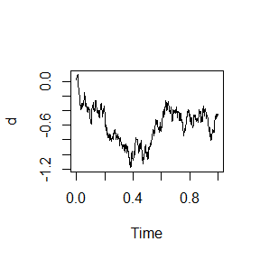

```r
fbm <- function(hurst=0.7, n=100){
  delta <- 1/n
  r <- numeric(n+1)
  r[1] <- 1
  for(k in 1:n)
    r[k+1] <- 0.5 * ((k+1)^(2*hurst) - 2*k^(2*hurst) + (k-1)^(2*hurst))
  r <- c(r, r[seq(length(r)-1, 2)])
  lambda <- Re((fft(r)) / (2*n))
  W <- fft(sqrt(lambda) * (rnorm(2*n) + rnorm(2*n)*1i))
  W <- n^(-hurst) * cumsum(Re(W[1:(n+1)]))
  X <- ts(W, start=0, deltat=delta)
  return(X)
}
d <- fbm(hurst=0.5, n=500)
plot(d)
```

The above picture show an Brownian movement.

The source R code for *Bs* is as follows:

```r
Bs <- function(n,m){
  f <- function(x) sin(12*(x+0.2))/(x+0.2)
  knots_eq <- function(x, k, m)
  {
    c(min(x) - ((k-1):0) * (max(x)-min(x))/(m+1),
      seq(from=min(x), to=max(x), length.out=m+2)[-c(1,m+2)],
      max(x) + (0:(k-1)) * (max(x)-min(x))/(m+1))
  }
  x=runif(n,0,1)
  e=rnorm(n,0,1)
  y=f(x)+e
  ks <- 1:6
  cols_k <- rainbow(length(ks))
  par(mai=c(0.65,0.6,0.1,0.1), mgp=c(2,1,0))
  plot(x, y, xlab="x", ylab="y", pch=16)
  abline(v=knots_eq(x, 1, m), lty=c(1,rep(2,m),1), col="grey60")
  for (kk in 1:length(ks))
  {
    k <- ks[kk]
    est <- lm(y ~ -1 +
                splineDesign(x=x, knots=knots_eq(x, k, m), ord=k))
    plot(function(x) splineDesign(x=x, knots=knots_eq(x, k, m), ord=k) %*%
           est$coef,
         from=min(x), to=max(x), n=1001, lwd=2, col=cols_k[kk], add=TRUE)
  }
  legend("bottomright", inset=0.02, legend=c(paste("k = ",ks,sep=""), "knots"),
         lwd=2, lty=c(rep(1,length(ks)),2), col=c(cols_k, "grey60"), bg="white")
}
```

The R code for using *Bs* is as follows.

```r
library("splines")
library("nlme")
library("MASS")
library("mgcv")
```

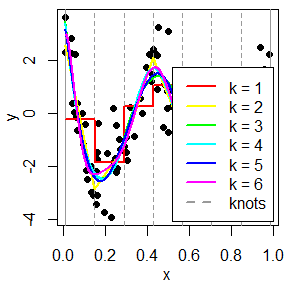

```r
Bs <- function(n,m){
  f <- function(x) sin(12*(x+0.2))/(x+0.2)
  knots_eq <- function(x, k, m)
  {
    c(min(x) - ((k-1):0) * (max(x)-min(x))/(m+1),
      seq(from=min(x), to=max(x), length.out=m+2)[-c(1,m+2)],
      max(x) + (0:(k-1)) * (max(x)-min(x))/(m+1))
  }
  x=runif(n,0,1)
  e=rnorm(n,0,1)
  y=f(x)+e
  ks <- 1:6
  cols_k <- rainbow(length(ks))
  par(mai=c(0.65,0.6,0.1,0.1), mgp=c(2,1,0))
  plot(x, y, xlab="x", ylab="y", pch=16)
  abline(v=knots_eq(x, 1, m), lty=c(1,rep(2,m),1), col="grey60")
  for (kk in 1:length(ks))
  {
    k <- ks[kk]
    est <- lm(y ~ -1 +
                splineDesign(x=x, knots=knots_eq(x, k, m), ord=k))
    plot(function(x) splineDesign(x=x, knots=knots_eq(x, k, m), ord=k) %*%
           est$coef,
         from=min(x), to=max(x), n=1001, lwd=2, col=cols_k[kk], add=TRUE)
  }
  legend("bottomright", inset=0.02, legend=c(paste("k = ",ks,sep=""), "knots"),
         lwd=2, lty=c(rep(1,length(ks)),2), col=c(cols_k, "grey60"), bg="white")
}
Bs(100,6)
```

The results show B-spline

## Homework in 20190925

## Question

Use knitr to produce at least 3 examples (texts, figures,tables).

## Answer

The mtcars is a data set about cars that R software comes with.

### summary of mtcars

```r
summary(mtcars)
```

```
##       mpg             cyl             disp             hp
##  Min.   :10.40   Min.   :4.000   Min.   : 71.1   Min.   : 52.0
##  1st Qu.:15.43   1st Qu.:4.000   1st Qu.:120.8   1st Qu.: 96.5
##  Median :19.20   Median :6.000   Median :196.3   Median :123.0
##  Mean   :20.09   Mean   :6.188   Mean   :230.7   Mean   :146.7
##  3rd Qu.:22.80   3rd Qu.:8.000   3rd Qu.:326.0   3rd Qu.:180.0
##  Max.   :33.90   Max.   :8.000   Max.   :472.0   Max.   :335.0
##       drat             wt             qsec             vs
##  Min.   :2.760   Min.   :1.513   Min.   :14.50   Min.   :0.0000
##  1st Qu.:3.080   1st Qu.:2.581   1st Qu.:16.89   1st Qu.:0.0000
##  Median :3.695   Median :3.325   Median :17.71   Median :0.0000
##  Mean   :3.597   Mean   :3.217   Mean   :17.85   Mean   :0.4375
##  3rd Qu.:3.920   3rd Qu.:3.610   3rd Qu.:18.90   3rd Qu.:1.0000
##  Max.   :4.930   Max.   :5.424   Max.   :22.90   Max.   :1.0000
##        am              gear            carb
##  Min.   :0.0000   Min.   :3.000   Min.   :1.000
##  1st Qu.:0.0000   1st Qu.:3.000   1st Qu.:2.000
##  Median :0.0000   Median :4.000   Median :2.000
##  Mean   :0.4062   Mean   :3.688   Mean   :2.812
##  3rd Qu.:1.0000   3rd Qu.:4.000   3rd Qu.:4.000
##  Max.   :1.0000   Max.   :5.000   Max.   :8.000
```

### example of figures

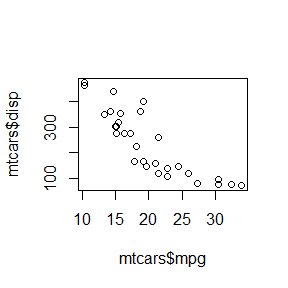

```r
plot(mtcars$mpg,mtcars$disp)
```

## Homework in 20191006

## Questions

- Exercises 3.4, 3.11, and 3.18 (pages 94-96, Statistical Computating with R).

## Answers

### 3.4

- In this question,we can easily calculate the corresponding distribution function:
  $$F(x)=1-e^{-\frac{x^2}{2\sigma^2}}$$
  Then we can get inverse function $F^{-1}(x)$:
  $$F^{-1}(x)=\sqrt{-2\sigma^2ln(1-x)}$$
  Then we can use the inverse transform method in Lec 1 Page 7. I choose the $\sigma$ is 0.5.

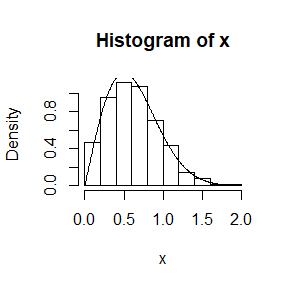

```r
### Nf is the inverse function.
Nf=function (Sigma,x)
{
  FN=((-2*Sigma^2*log(1-x)))^0.5
  FN
}

### pdf is the  Rayleigh density function.
pdf=function (Sigma,x)
{
  f=x/Sigma^2*exp(-x^2/(2*Sigma^2))
  f
}
n <- 1000
u <- runif(n)
Sigma=0.5 #Here we can change Sigma
x <- Nf(Sigma,u)
hist(x, prob = TRUE)
y <- seq(0, 2, .005)
lines(y, pdf(Sigma,y))
```

### 3.11

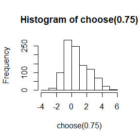

```r
n=1000
x1=rnorm(n,0,1)
x2=rnorm(n,3,1)
choose=function(p)
{
  p.new=sample(c(0,1),n,replace = TRUE,prob = c(1-p,p))
  ### The probility that p.new is 1 is p,the probility that p.new is 0 is 1-p.
  X=p.new*x1+(1-p.new)*x2
  X
}

f=function(x,mu)
{
  f=exp(-(x-mu)^2/2)*(2*pi)^(-0.5)
  f
}


hist(choose(0.75))
```

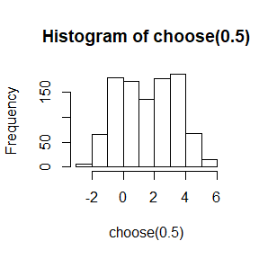

```r
hist(choose(0.5))
```

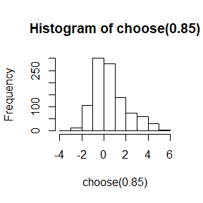

```r
hist(choose(0.85))
```

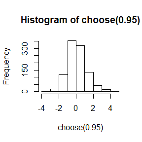

```r
hist(choose(0.95))
```

## Homework in 20191011

## Question

1. Compute a Monte Carlo estimate of
   $$\int_{0}^{\pi /3}sint\ dt$$
   and compare your estimate with the exact value of the integral.
2. Use Monte Carlo integration with antithetic variables to estimate
   $$\int_{0}^{1}\frac{e^{-x}}{1+x^{2}}\ dx$$
   and find the approximate reduction in variance as a percentage of the variance without variance reduction.
3. Obtain the stratified importance sampling estimate in Example 5.13 and compare it with the result of Example 5.10.

## Question 1(5.1)

- This question I used Antithetic variables to solve this question.
- $$\int_{0}^{\pi /3}sint\ dt =cos\left (0 \right )-cos\left ( \frac{\pi }{3} \right )=0.5$$
- The exact value of the integral is 0.5.

```r
n=1e4
x=runif(n,min=0,max=pi/3)
theta_hat1=mean(sin(x))*(pi/3)
theta_hat2=mean(sin(pi/3-x))*(pi/3)
theta_hat=mean(c(theta_hat1,theta_hat2))
print(c(theta_hat1,theta_hat2))
```

```
## [1] 0.5036189 0.4963341
```

```r
print(theta_hat)
```

```
## [1] 0.4999765
```

- The error is 2.347496210^{-5}.

## Question 2(5.10)

- This method is my initial idea, but the calculation efficiency is very low, but the result is very good.

```r
theta_hat_MC=theta_hat_AhV=0
for (i in 1:1000){
  n=1e4
  x=runif(n,min=0,max=1)
  theta=exp(-x)/(1+x^2)
  theta_hat_MC[i]=mean(theta)
  theta_NI=exp(-(1-x))/(1+(1-x)^2)
  theta_hat_AhV[i]=mean(c(theta[1:(n/2)],theta_NI[1:(n/2)]))
}
c(sd(theta_hat_MC)^2,sd(theta_hat_AhV)^2,sd(theta_hat_AhV)^2/sd(theta_hat_MC)^2)
```

```
## [1] 6.223652e-06 2.325347e-07 3.736306e-02
```

- We can apply the ready-made code on P120 of the textbook.

```r
MC.Phi <- function(x, R = 10000, antithetic = TRUE) {
  u <- runif(R/2,0,x)
  if (!antithetic) v <- runif(R/2) else v <- 1 - u
  u <- c(u, v)
  cdf <- numeric(length(x))
  for (i in 1:length(x)) {
    g <- exp(-u)/(1+u^2)
    cdf[i] <- mean(g)
  }
  cdf
}
m <- 1000
MC1 <- MC2 <- numeric(m)
x <- 1
for (i in 1:m) {
  MC1[i] <- MC.Phi(x, R = 1000, anti = FALSE)
  MC2[i] <- MC.Phi(x, R = 1000)
}

c(sd(MC1)^2,sd(MC2)^2,sd(MC2)^2/sd(MC1)^2)
```

```
## [1] 5.863301e-05 2.234564e-06 3.811102e-02
```

## Question 3(5.15)

```r
M <- 10000; k <- 5
r <- M/k #replicates per stratum
N <- 50 #number of times to repeat the estimation
T2 <- numeric(k)
est <- 0
g<-function(x) exp(-x - log(1+x^2)) * (x > 0) * (x < 1) / (exp(-x) / (1 - exp(-1)))
for (i in 1:N) {
  for(j in 1:k)
    {
      u=runif(r,(j-1)/k,j/k)
      x = -log(1 - u * (1 - exp(-1)))
      fg <- g(x)
      T[j]<-mean(fg)
    }
  est[i] <- mean(T)
}
mean(est)
```

```
## [1] 0.5247979
```

```r
sd(est)
```

```
## [1] 0.0002193257
```

- The mean using the the stratified importance sampling estimate method is 0.5247979,is similar to $\hat{\theta}=0.5257801$
- The standard deviation we get using the the stratified importance sampling estimate method is 2.193257210^{-4},the estimated standard error in Example 5.10 is 0.0970314,so the stratified importance sampling estimate method is better in this question.

## Homework in 20191018

## 6.5

### Question

- Suppose a 95% symmetric t-interval is applied to estimate a mean, but the sample data are non-normal. Then the probability that the confidence interval covers the mean is not necessarily equal to 0.95. Use aMonte Carlo experiment to estimate the coverage probability of the t-interval for random samples of $\chi^{2}(2)$ data with sample size n = 20. Compare your t-interval results with the simulation results in Example 6.4. (The t-interval should be more robust to departures from normality than the interval for variance.)

### Answer

```r
n <- 20
alpha <- 0.05
UCL <- sigma_hat <- theta_hat <- 0

### repete 1000 times
for (i in 1:1000)
{
  x<- rchisq(n,df=2)
  theta_hat[i]=mean(x)
  sigma_hat[i]=sd(x)
  UCL[i] <- (n-1) * var(x) / qchisq(alpha, df=n-1)
}

### t-interval method
mean(theta_hat-qt(1-alpha/2,n-2)*sigma_hat/sqrt(n)<=2 & theta_hat+qt(1-alpha/2,n-2)*sigma_hat/sqrt(n)>=2)
```

```
## [1] 0.925
```

```r
### method in example 6.4
mean(UCL>=4)
```

```
## [1] 0.778
```

- From the result,we can find t-interval method is better than the method used interval for variance.

## 6.6

### Question

- Estimate the 0.025, 0.05, 0.95, and 0.975 quantiles of the skewness $\sqrt{b_{1}}$ under normality by a Monte Carlo experiment. Compute the standard error of the estimates from (2.14) using the normal approximation for the density (with exact variance formula). Compare the estimated quantiles with the quantiles of the large sample approximation $\sqrt{b_{1}}\approx N(0, 6/n)$.

### Answer

```r
n <- 20
rep=1000
skewness <- 0
q=c(0.025,0.05,0.95,0.975)

sk <- function(x) {
#computes the sample skewness coeff.
xbar <- mean(x)
m3 <- mean((x - xbar)^3)
m2 <- mean((x - xbar)^2)
return( m3 / m2^1.5 )
}

for (i in 1:rep){
  x <- rnorm(n,0,1)
  skewness[i]=sk(x)
}

### the estimated quantiles
cv_hat=as.vector(quantile(skewness,q))
cv_hat
```

```
## [1] -0.9436183 -0.7671857  0.7257385  0.8940831
```

```r
### the real data
cv <- qnorm(q,0, sqrt(6/n))
cv
```

```
## [1] -1.0735165 -0.9009234  0.9009234  1.0735165
```

```r
### the error is:
1-cv_hat/cv
```

```
## [1] 0.1210025 0.1484451 0.1944504 0.1671455
```

```r
### Because we get a small number of skewness, we change the variance of the skewness to 6*(n-2) / ((n+1)*(n+3)
cv <- qnorm(q,0, sqrt(6*(n-2)/((n+1)*(n+3))))
### Revised cv is
cv
```

```
## [1] -0.9268008 -0.7777958  0.7777958  0.9268008
```

```r
### the revised error is:
1-cv_hat/cv
```

```
## [1] -0.01814579  0.01364115  0.06692918  0.03530182
```

```r
### The result is much better.

### When q=c(0.025,0.05,0.95,0.975),the standard error is
q*(1-q)/(n*(exp(-cv_hat^2)/sqrt(2*pi)))
```

```
## [1] 0.007442299 0.010724276 0.010080797 0.006794740
```

## Solution

```r
alpha <- .1
n <- seq(100,2000,100)
m <- 2500
sk <- function(x) {
#computes the sample skewness coeff.
xbar <- mean(x)
m3 <- mean((x - xbar)^3)
m2 <- mean((x - xbar)^2)
return( m3 / m2^1.5 )
}
power=0
for (j in 1:length(n)){
  #critical value for the skewness test
  cv <- qnorm(1-alpha/2, 0, sqrt(6*(n[j]-2) / ((n[j]+1)*(n[j]+3))))
  sktests <- numeric(m)
  for (i in 1:m) { #for each replicate
  x <- rbeta(n[j],alpha,alpha)
  sktests[i] <- as.integer(abs(sk(x)) >= cv)
  }
power[j]=mean(sktests)
}
power
```

```
##  [1] 0.0452 0.0332 0.0500 0.0348 0.0380 0.0344 0.0348 0.0320 0.0316 0.0328
## [11] 0.0388 0.0296 0.0260 0.0312 0.0352 0.0316 0.0348 0.0368 0.0332 0.0304
```

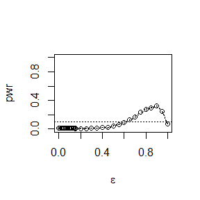

```r
alpha <- .1
n <- 30
m <- 2500
epsilon <- c(seq(0, .15, .01), seq(.15, 1, .05))
N <- length(epsilon)
pwr <- numeric(N)
sk <- function(x) {
#computes the sample skewness coeff.
xbar <- mean(x)
m3 <- mean((x - xbar)^3)
m2 <- mean((x - xbar)^2)
return( m3 / m2^1.5 )
}
#critical value for the skewness test
cv <- qnorm(1-alpha/2, 0, sqrt(6*(n-2) / ((n+1)*(n+3))))
for (j in 1:N) { #for each epsilon
e <- epsilon[j]
sktests <- numeric(m)
for (i in 1:m) { #for each replicate
sigma <- sample(c(1, 10), replace = TRUE,
size = n, prob = c(1-e, e))
## x <- rnorm(n, 0, sigma)
x <- rbeta(n,sigma,sigma)
sktests[i] <- as.integer(abs(sk(x)) >= cv)
}
pwr[j] <- mean(sktests)
}
#plot power vs epsilon
plot(epsilon, pwr, type = "b",
xlab = bquote(epsilon), ylim = c(0,1))
abline(h = .1, lty = 3)
se <- sqrt(pwr * (1-pwr) / m) #add standard errors
lines(epsilon, pwr+se, lty = 3)
lines(epsilon, pwr-se, lty = 3)
```

## Question 2

- Use Monte Carlo simulation to investigate whether the empirical Type I error rate of the t-test is approximately equal to the nominal significance level $\alpha$, when the sampled population is non-normal. The t-test is robust to mild departures from normality. Discuss the simulation results for the cases where the sampled population is (i) $\chi^{2}(1)$, (ii)Uniform(0,2), and (iii) Exponential(rate=1). In each case, test $H_{0} : μ = \mu_{0}$ vs $H_{1}:μ\neq\mu_{0}$, where $\mu_{0}$ is the mean of $\chi^{2}_{1}$, Uniform(0,2), and Exponential(1), respectively.